# acumen benchmark report

Generated 2026-10-27 19:11 UTC · 168 runs · figures show the valid split · arms: noskill, v1, v2 · tasks: annotate, ccc, embed, grouptest, markers, mofa, pbde, programs, qc, signature, tfact, traj

## Overview

Per-run means over the valid split; error bars are standard errors.

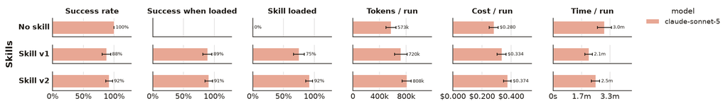

### Success across versions

Each line follows one model's success rate as the skill goes from no skill through each version. Solid lines are the valid tasks and dashed lines are the train tasks. The grey line is the mean across models and sits on top. The newest version has only valid runs, so the train lines stop one step short.

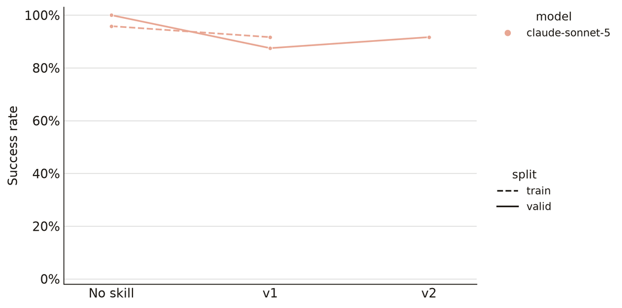

### Cost vs. success

One mark per model and skill version, where colour is the model and the ✕ is that model's no-skill baseline. Arrows join one model's own marks in version order, baseline to v1 to v2 and on, so a chain is that model's path and never crosses to another. The grey mark pools every model for that version, with standard errors on both axes, and its chain is the pooled path. The staircase is the Pareto frontier: anything below and to the right of it is dominated, because something on the line costs less *and* succeeds more.

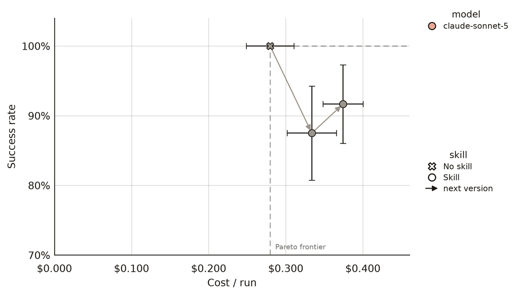

### Is the difference real?

Each version is compared with the baseline on two separate questions: does it succeed more often, and does it cost less per run? Each is a one-sided test, and each is corrected on its own, with a Benjamini–Hochberg false-discovery rate (*FDR q*) across the versions. Success is one family and cost is another, so a version can show a real gain on success, on cost, or on both, and the table says which. A gain the resampling cannot tell apart from noise leaves q high, which says the evidence is thin rather than that the version is bad. Best value in each column is **bold**, highest for the rates and lowest for cost and for the p- and q-values. *On frontier* is how often an arm holds the Pareto frontier across resamples. Resampling is over the 12 tasks, paired across arms, so the unit is the task rather than the run.

| Skill | Success rate | Cost / run | On frontier | Success vs No skill Δ rate | Success vs No skill p | Success vs No skill FDR q | Cost vs No skill Δ cost | Cost vs No skill p | Cost vs No skill FDR q |
| --- | --- | --- | --- | --- | --- | --- | --- | --- | --- |
| No skill | **100.0%** | **$0.280** | **98.8%** | — | — | — | — | — | — |
| Skill v1 | 87.5% | $0.334 | 11.4% | -12.5pp | **1.000** | **1.000** | **+$0.054** | **0.885** | **0.990** |
| Skill v2 | 91.7% | $0.374 | 0.5% | **-8.3pp** | **1.000** | **1.000** | +$0.095 | 0.990 | **0.990** |

### Did it help when it actually loaded?

If a skill never loads, the agent never reads it, so that run tells us nothing about the skill itself and only measures the baseline. Setting those runs aside lets us see whether the guidance helped in the runs where it did reach the agent. This helps tell apart a skill that fails to load from one that loads but still doesn't help. In the plot below, every dot is one model on one skill version. The colour shows the change in success rate against the baseline, green for better and red for worse. The size shows how often the skill loaded, and a hollow ring means it never did. Each loaded run is compared with the baseline on the very same task and model, and those differences are averaged, so the number is a real effect and does not depend on which tasks happened to load. It is still measured only on the tasks that loaded, and it does not test whether a gain is more than noise. For that, look at the significance test above.

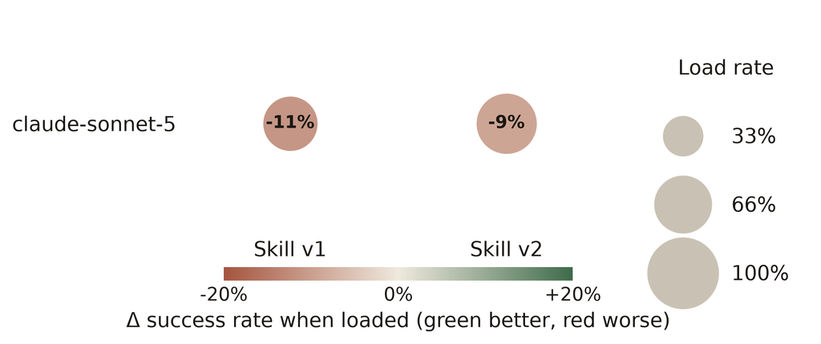

## Held-out test

This is the truly held-out split. It is benched once at the very end of a fit, on the best kept version and the baseline, and nothing in the loop ever sees it. Training learns from the train split and the best version is picked on valid, so the test split is the first and only place the skill meets these tasks. Read it as the honest final estimate of what the skill buys.

Skill version used for the held-out test: **v2**, the best on validation and the version to ship (`acumen ship --skill v2`).

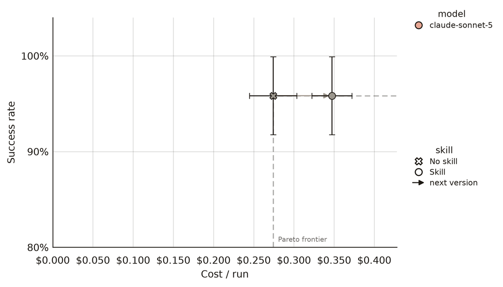

| Skill | Success rate | Cost / run | On frontier | Success vs No skill Δ rate | Success vs No skill p | Success vs No skill FDR q | Cost vs No skill Δ cost | Cost vs No skill p | Cost vs No skill FDR q |
| --- | --- | --- | --- | --- | --- | --- | --- | --- | --- |
| No skill | **95.8%** | **$0.274** | **99.9%** | — | — | — | — | — | — |
| Skill v2 | **95.8%** | $0.347 | 0.1% | +0.0pp | 1.000 | 1.000 | +$0.073 | 0.999 | 0.999 |

## Per-task breakdown

### annotate

**train:** `core_kang_stim_ref.h5ad` in the working directory holds the interferon-beta stimulated PBMCs of Kang et al. 2018: raw UMI counts in `X`, `obs` column `cell_type`. `core_kang_ctrl_query.h5ad` holds the control PBMCs: raw UMI counts in `X`, a UMAP in `obsm['X_umap']`, `obs` columns `replicate` and `cell_type`. `core_pbmc_markers.tsv` lists marker genes per label (columns `label`, `gene`). Transfer labels from the stimulated cells to the control cells with CellTypist: normalise copies of both to 10,000 counts per cell, then log1p; train a model on the stimulated cells by `cell_type` with `celltypist.train` (default solver, n_jobs 1, random state 0); annotate the control cells with it in best-match mode without majority voting. Tabulate the transferred labels by the control cells' `cell_type`, and check them against the marker genes in a dot plot. Save the annotated h5ad, the tables and the figures in the working directory. Report only the number of control cells with `cell_type` CD8 T cells whose transferred label is also CD8 T cells. Genome reference: GRCh37 (hg19), 10x Cell Ranger hg19 annotation.

**valid:** `core_kang_stim_ref.h5ad` in the working directory holds the interferon-beta stimulated PBMCs of Kang et al. 2018: raw UMI counts in `X`, `obs` column `cell_type`. `core_kang_ctrl_query.h5ad` holds the control PBMCs: raw UMI counts in `X`, a UMAP in `obsm['X_umap']`, `obs` columns `replicate` and `cell_type`. `core_pbmc_markers.tsv` lists marker genes per label (columns `label`, `gene`). Transfer labels from the stimulated cells to the control cells with CellTypist: normalise copies of both to 10,000 counts per cell, then log1p; train a model on the stimulated cells by `cell_type` with `celltypist.train` (default solver, n_jobs 1, random state 0); annotate the control cells with it in best-match mode without majority voting. Tabulate the transferred labels by the control cells' `cell_type`, and check them against the marker genes in a dot plot. Save the annotated h5ad, the tables and the figures in the working directory. Report only the number of control cells with `cell_type` NK cells whose transferred label is also NK cells. Genome reference: GRCh37 (hg19), 10x Cell Ranger hg19 annotation.

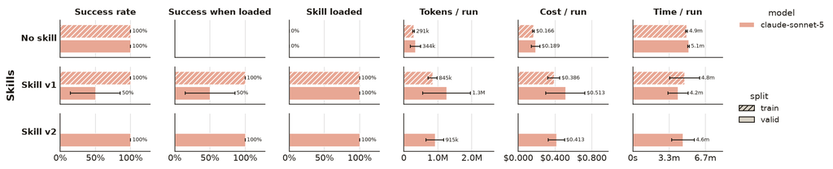

### ccc

**train:** `kang2018_lognorm.h5ad` in the working directory holds Kang et al. 2018 PBMCs: log-normalised values in `X` (`normalize_total` to 10,000 then `log1p`); `obs` columns `sample` (one id per patient x condition, e.g. `patient_101_ctrl`), `replicate` (patient), `label` (`ctrl` or `stim`, interferon-beta) and `cell_type`. Take the `ctrl` cells. `liana_consensus.tsv` is liana's consensus ligand-receptor resource (columns `ligand`, `receptor`). Run liana's rank aggregate of all five methods (CellPhoneDB, Connectome, log2FC, NATMI, SingleCellSignalR) between all `cell_type` pairs with this resource: expr_prop 0.1, min_cells 5, n_perms 100, seed 0, use_raw False, one job and one BLAS thread. An interaction passes when magnitude_rank <= 0.01 and specificity_rank <= 0.05. Save the results tables and figures in the working directory. Report only the number of passing interactions. Genome reference: GRCh37 (hg19), 10x Cell Ranger hg19 annotation.

**valid:** `kang2018_lognorm.h5ad` in the working directory holds Kang et al. 2018 PBMCs: log-normalised values in `X` (`normalize_total` to 10,000 then `log1p`); `obs` columns `sample` (one id per patient x condition, e.g. `patient_101_ctrl`), `replicate` (patient), `label` (`ctrl` or `stim`, interferon-beta) and `cell_type`. Take the `stim` cells. `liana_consensus.tsv` is liana's consensus ligand-receptor resource (columns `ligand`, `receptor`). Run liana's rank aggregate of all five methods (CellPhoneDB, Connectome, log2FC, NATMI, SingleCellSignalR) between all `cell_type` pairs with this resource: expr_prop 0.1, min_cells 5, n_perms 100, seed 0, use_raw False, one job and one BLAS thread. An interaction passes when magnitude_rank <= 0.01 and specificity_rank <= 0.05. Save the results tables and figures in the working directory. Report only the number of passing interactions. Genome reference: GRCh37 (hg19), 10x Cell Ranger hg19 annotation.

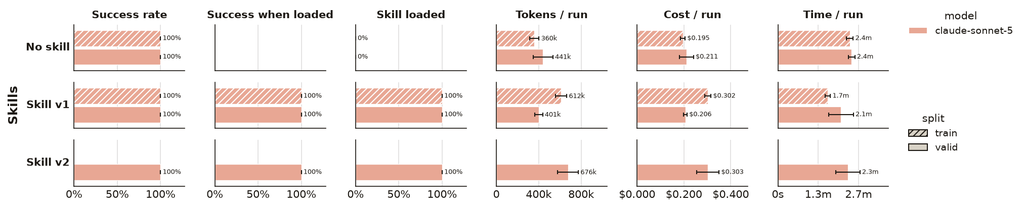

### embed

**train:** `kang2018.h5ad` in the working directory holds Kang et al. 2018 PBMCs: raw UMI counts in `X`; `obs` columns `label` (`ctrl` or `stim`, interferon-beta), `replicate` (patient id) and `cell_type`. Embed and cluster the CD8 T cells, both conditions together. Keep the raw counts in a layer; normalise each cell to 10,000 total counts, then log1p. Pick the 2,000 most highly variable genes with the `seurat` flavor on the log-normalised data, with `replicate` as the batch key. Scale those genes to zero mean and unit variance with no clipping and run PCA with 30 components and the ARPACK solver. Integrate the PCs by `replicate` with harmonypy's `run_harmony` (at most 20 iterations). Build a 15-neighbour kNN graph on the first 20 Harmony-corrected components, compute a UMAP with min_dist 0.3, and run Leiden clustering (igraph flavor, 2 iterations, undirected graph) at resolution 0.4. Use seed 0 for PCA, Harmony, neighbours, UMAP and Leiden. Save the embedded h5ad, a cluster-size table and UMAP figures in the working directory. Report only the number of Leiden clusters. Genome reference: GRCh37 (hg19), 10x Cell Ranger hg19 annotation.

**valid:** `kang2018.h5ad` in the working directory holds Kang et al. 2018 PBMCs: raw UMI counts in `X`; `obs` columns `label` (`ctrl` or `stim`, interferon-beta), `replicate` (patient id) and `cell_type`. Embed and cluster the NK cells, both conditions together. Keep the raw counts in a layer; normalise each cell to 10,000 total counts, then log1p. Pick the 2,000 most highly variable genes with the `seurat` flavor on the log-normalised data, with `replicate` as the batch key. Scale those genes to zero mean and unit variance with no clipping and run PCA with 30 components and the ARPACK solver. Integrate the PCs by `replicate` with harmonypy's `run_harmony` (at most 20 iterations). Build a 15-neighbour kNN graph on the first 20 Harmony-corrected components, compute a UMAP with min_dist 0.3, and run Leiden clustering (igraph flavor, 2 iterations, undirected graph) at resolution 0.5. Use seed 0 for PCA, Harmony, neighbours, UMAP and Leiden. Save the embedded h5ad, a cluster-size table and UMAP figures in the working directory. Report only the number of Leiden clusters. Genome reference: GRCh37 (hg19), 10x Cell Ranger hg19 annotation.

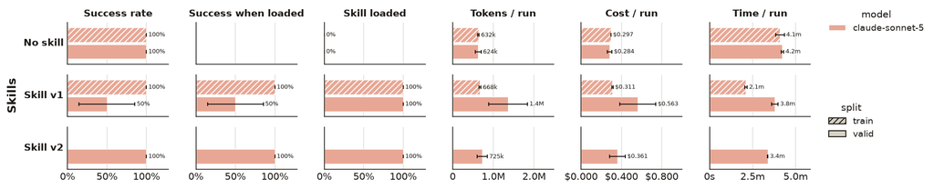

### grouptest

**train:** `kang2018_lognorm.h5ad` in the working directory holds Kang et al. 2018 PBMCs: log-normalised values in `X` (`normalize_total` to 10,000 then `log1p`); `obs` columns `sample` (one id per patient x condition, e.g. `patient_101_ctrl`), `replicate` (patient), `label` (`ctrl` or `stim`, interferon-beta) and `cell_type`. Take the cells whose `cell_type` is CD4 T cells. For each `sample`, compute the mean log-normalised value over its cells of each of these 30 genes: ISG15, IFI6, IFIT1, IFIT3, MX1, OAS1, IFITM3, LY6E, STAT1, IRF7, CD3E, CD14, LYZ, MS4A1, NKG7, GNLY, ACTB, GAPDH, B2M, CCL5, S100A8, S100A9, FCGR3A, HLA-DRA, CD74, IL7R, CCR7, FTL, FTH1, TMSB4X. Test each gene stim vs ctrl with a two-sided paired Wilcoxon signed-rank test, pairing the two samples of each `replicate` (ctrl is the reference, so differences are stim minus ctrl; complete pairs only; zero differences dropped; exact p-values as scipy gives for 8 pairs). Correct across the genes with Benjamini-Hochberg. A gene is significant when the adjusted p-value < 0.05. Save the results tables and figures in the working directory. Report only the number of significant genes. Genome reference: GRCh37 (hg19), 10x Cell Ranger hg19 annotation.

**valid:** `kang2018_lognorm.h5ad` in the working directory holds Kang et al. 2018 PBMCs: log-normalised values in `X` (`normalize_total` to 10,000 then `log1p`); `obs` columns `sample` (one id per patient x condition, e.g. `patient_101_ctrl`), `replicate` (patient), `label` (`ctrl` or `stim`, interferon-beta) and `cell_type`. Take the cells whose `cell_type` is NK cells. For each `sample`, compute the mean log-normalised value over its cells of each of these 30 genes: ISG15, IFI6, IFIT1, IFIT3, MX1, OAS1, IFITM3, LY6E, STAT1, IRF7, CD3E, CD14, LYZ, MS4A1, NKG7, GNLY, ACTB, GAPDH, B2M, CCL5, S100A8, S100A9, FCGR3A, HLA-DRA, CD74, IL7R, CCR7, FTL, FTH1, TMSB4X. Test each gene stim vs ctrl with a two-sided paired Wilcoxon signed-rank test, pairing the two samples of each `replicate` (ctrl is the reference, so differences are stim minus ctrl; complete pairs only; zero differences dropped; exact p-values as scipy gives for 8 pairs). Correct across the genes with Benjamini-Hochberg. A gene is significant when the adjusted p-value < 0.1. Save the results tables and figures in the working directory. Report only the number of significant genes. Genome reference: GRCh37 (hg19), 10x Cell Ranger hg19 annotation.

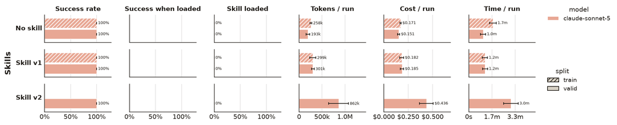

### markers

**train:** `kang2018.h5ad` in the working directory holds Kang et al. 2018 PBMCs: raw UMI counts in `X`; `obs` columns `label` (`ctrl` or `stim`, interferon-beta), `replicate` (patient id) and `cell_type`. Find marker genes for each `cell_type` among the ctrl cells only. Normalise each cell to 10,000 total counts, then log1p. Test each cell type against all other cells with a Wilcoxon rank-sum test (scanpy `rank_genes_groups`, every gene, Benjamini-Hochberg correction, on the log-normalised values, not `.raw`). A gene is a marker of a cell type when its adjusted p < 0.05, its log2 fold change (scanpy's, up in that type) > 1, and it is detected (value > 0) in at least 0.25 of that type's cells. Save the full marker table, a dot plot and a heatmap of the top 5 markers per cell type in the working directory. Report only the number of markers of B cells. Genome reference: GRCh37 (hg19), 10x Cell Ranger hg19 annotation.

**valid:** `kang2018.h5ad` in the working directory holds Kang et al. 2018 PBMCs: raw UMI counts in `X`; `obs` columns `label` (`ctrl` or `stim`, interferon-beta), `replicate` (patient id) and `cell_type`. Find marker genes for each `cell_type` among the stim cells only. Normalise each cell to 10,000 total counts, then log1p. Test each cell type against all other cells with a Wilcoxon rank-sum test (scanpy `rank_genes_groups`, every gene, Benjamini-Hochberg correction, on the log-normalised values, not `.raw`). A gene is a marker of a cell type when its adjusted p < 0.01, its log2 fold change (scanpy's, up in that type) > 1.5, and it is detected (value > 0) in at least 0.3 of that type's cells. Save the full marker table, a dot plot and a heatmap of the top 5 markers per cell type in the working directory. Report only the number of markers of NK cells. Genome reference: GRCh37 (hg19), 10x Cell Ranger hg19 annotation.

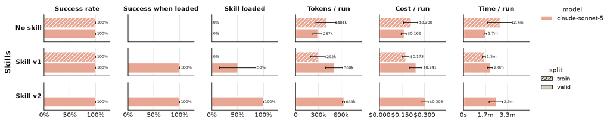

### mofa

**train:** The directory `struct_mofa/` in the working directory holds pseudobulk views of Kang et al. 2018 PBMCs, 16 samples (8 patients x `ctrl`/`stim` interferon-beta): one TSV per cell type named `<view>.tsv`, samples in rows (first column `sample`), log2(CPM + 1) features named `<view>_<gene>`; and `meta.tsv` with columns `sample`, `label` and `replicate`. Run MOFA2 (mofapy2) on the views `b`, `mono14`, `nk`: every view Gaussian, 5 factors, views scaled to unit variance, convergence mode `fast`, seed 0, no factor dropped during training (`dropR2=None`), on CPU. Sort views, samples and features before building the model. Number the factors in the order of the saved model (mofapy2 sorts them by variance explained when saving), so Factor1 explains the most. A factor is active when its variance explained (R², in %) is >= 15 in at least one view. Colour and test factors by `label`. Save the result tables and figures in the working directory. Report only `<view in which Factor1 has the largest R²>/<number of active factors>`, for example `cd8t/3`. Genome reference: GRCh37 (hg19), 10x Cell Ranger hg19 annotation.

**valid:** The directory `struct_mofa/` in the working directory holds pseudobulk views of Kang et al. 2018 PBMCs, 16 samples (8 patients x `ctrl`/`stim` interferon-beta): one TSV per cell type named `<view>.tsv`, samples in rows (first column `sample`), log2(CPM + 1) features named `<view>_<gene>`; and `meta.tsv` with columns `sample`, `label` and `replicate`. Run MOFA2 (mofapy2) on the views `cd4t`, `cd8t`, `mono16`: every view Gaussian, 5 factors, views scaled to unit variance, convergence mode `fast`, seed 1, no factor dropped during training (`dropR2=None`), on CPU. Sort views, samples and features before building the model. Number the factors in the order of the saved model (mofapy2 sorts them by variance explained when saving), so Factor1 explains the most. A factor is active when its variance explained (R², in %) is >= 5 in at least one view. Colour and test factors by `label`. Save the result tables and figures in the working directory. Report only `<view in which Factor1 has the largest R²>/<number of active factors>`, for example `cd8t/3`. Genome reference: GRCh37 (hg19), 10x Cell Ranger hg19 annotation.

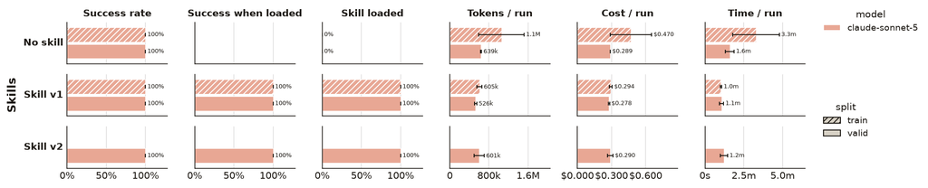

### pbde

**train:** `kang2018_pb.h5ad` in the working directory holds Kang et al. 2018 PBMCs: raw UMI counts in `X`; `obs` columns `sample` (one id per patient x condition), `replicate` (patient), `label` (`ctrl` or `stim`, interferon-beta) and `cell_type`. Pseudobulk the FCGR3A+ Monocytes: sum raw counts per `sample` over that cell type's cells; drop samples with fewer than 20 cells; keep genes detected (count > 0) in at least 0.2 of the cells of the kept samples. Then test stim vs ctrl with PyDESeq2: design `~ replicate + label`, no fold-change shrinkage, independent-filtering alpha 0.01. A gene is significant when padj < 0.01 and |log2 fold change| > 1.5; a missing padj is not significant. Save the result tables and figures in the working directory. Report only `<significant genes up in stim>/<significant genes down in stim>`, for example `120/45`. Genome reference: GRCh37 (hg19), 10x Cell Ranger hg19 annotation.

**valid:** `kang2018_pb.h5ad` in the working directory holds Kang et al. 2018 PBMCs: raw UMI counts in `X`; `obs` columns `sample` (one id per patient x condition), `replicate` (patient), `label` (`ctrl` or `stim`, interferon-beta) and `cell_type`. Pseudobulk the CD4 T cells: sum raw counts per `sample` over that cell type's cells; drop samples with fewer than 100 cells; keep genes detected (count > 0) in at least 0.15 of the cells of the kept samples. Then test stim vs ctrl with PyDESeq2: design `~ replicate + label`, no fold-change shrinkage, independent-filtering alpha 0.05. A gene is significant when padj < 0.05 and |log2 fold change| > 2; a missing padj is not significant. Save the result tables and figures in the working directory. Report only `<significant genes up in stim>/<significant genes down in stim>`, for example `120/45`. Genome reference: GRCh37 (hg19), 10x Cell Ranger hg19 annotation.

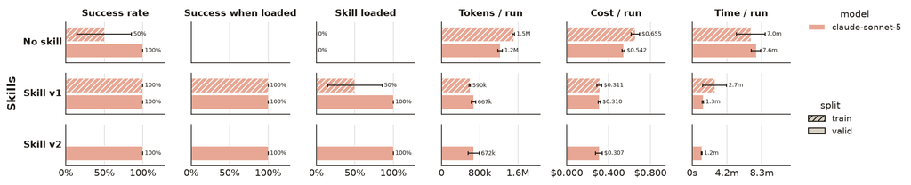

### programs

**train:** `kang2018.h5ad` in the working directory holds Kang et al. 2018 PBMCs: raw UMI counts in `X`; `obs` columns `label` (`ctrl` or `stim`, interferon-beta), `replicate` (patient id) and `cell_type`. Find gene programs by consensus NMF (cNMF-style) in the B cells of patients patient_1015 and patient_1488 (`replicate`). (1) HVGs: among genes with non-zero total counts in this subset, the top 500 by scanpy `highly_variable_genes(flavor='seurat')` on a copy run through `normalize_total(target_sum=1e4)` and `log1p`. (2) NMF input: the raw counts of those HVGs, each gene divided by its standard deviation over cells (population sd, not centred). (3) Fit scikit-learn `NMF` 12 times with 3 components, `init='random'`, `solver='cd'`, Frobenius loss, `max_iter=1000`; run i uses `random_state` equal to element i of `numpy.random.default_rng(0).integers(1, 2**31 - 1, 12)`. (4) Consensus: L2-normalise each of the 3 x 12 components and keep all of them (no density filter); cluster them with `KMeans(n_clusters=3, n_init=10, random_state=0)`; the element-wise median of each cluster, scaled to sum 1, is a consensus spectrum. (5) Usage: `non_negative_factorization` of the NMF input with the consensus spectra fixed (`update_H=False`, `solver='cd'`, `max_iter=1000`), then scale each cell's usage to sum 1. (6) Name the programs GP1 to GP3 by total usage over cells, largest first. (7) Gene scores, for every gene expressed in the subset: z-score each gene's TPM (counts scaled to 1e6 per cell; population sd) over cells, then take the least-squares coefficients `pinv(usage) @ Z`. The program most active in stim cells is the one whose usage has the highest one-vs-rest ROC AUC for `label` stim. Save the result tables and figures in the working directory. Report only `<program name>/<its highest-scoring gene>`, for example `GP3/CD74`. Genome reference: GRCh37 (hg19), 10x Cell Ranger hg19 annotation.

**valid:** `kang2018.h5ad` in the working directory holds Kang et al. 2018 PBMCs: raw UMI counts in `X`; `obs` columns `label` (`ctrl` or `stim`, interferon-beta), `replicate` (patient id) and `cell_type`. Find gene programs by consensus NMF (cNMF-style) in the NK cells of patients patient_1256 and patient_1488 (`replicate`). (1) HVGs: among genes with non-zero total counts in this subset, the top 800 by scanpy `highly_variable_genes(flavor='seurat')` on a copy run through `normalize_total(target_sum=1e4)` and `log1p`. (2) NMF input: the raw counts of those HVGs, each gene divided by its standard deviation over cells (population sd, not centred). (3) Fit scikit-learn `NMF` 12 times with 4 components, `init='random'`, `solver='cd'`, Frobenius loss, `max_iter=1000`; run i uses `random_state` equal to element i of `numpy.random.default_rng(0).integers(1, 2**31 - 1, 12)`. (4) Consensus: L2-normalise each of the 4 x 12 components and keep all of them (no density filter); cluster them with `KMeans(n_clusters=4, n_init=10, random_state=0)`; the element-wise median of each cluster, scaled to sum 1, is a consensus spectrum. (5) Usage: `non_negative_factorization` of the NMF input with the consensus spectra fixed (`update_H=False`, `solver='cd'`, `max_iter=1000`), then scale each cell's usage to sum 1. (6) Name the programs GP1 to GP4 by total usage over cells, largest first. (7) Gene scores, for every gene expressed in the subset: z-score each gene's TPM (counts scaled to 1e6 per cell; population sd) over cells, then take the least-squares coefficients `pinv(usage) @ Z`. The program most active in stim cells is the one whose usage has the highest one-vs-rest ROC AUC for `label` stim. Save the result tables and figures in the working directory. Report only `<program name>/<its highest-scoring gene>`, for example `GP3/CD74`. Genome reference: GRCh37 (hg19), 10x Cell Ranger hg19 annotation.

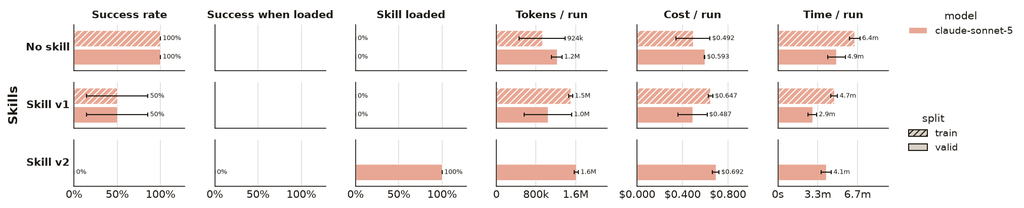

### qc

**train:** `core_pbmc3k.h5ad` in the working directory holds the 10x PBMC 3k library: raw UMI counts in `X`, gene symbols as `var_names`, and `obs` column `sample` (one library). Run cell QC and doublet removal. Compute per-cell QC metrics on the raw counts; mitochondrial genes start with `MT-`. Score doublets on all cells before any filtering with scanpy's `sc.pp.scrublet`, per `sample`: expected doublet rate 0.06, 30 principal components, exact nearest neighbours (no approximate search), random state 0, and Scrublet's own automatic threshold; a cell is a doublet when its score exceeds that threshold. Keep a cell when it has 200 to 2500 genes detected (inclusive), at least 500 UMI counts, at most 5% mitochondrial counts, and is not a predicted doublet. Save the filtered h5ad, a per-cell QC table and QC figures in the working directory. Report only the number of cells kept. Genome reference: GRCh37 (hg19), 10x Cell Ranger hg19 annotation.

**valid:** `core_pbmc3k.h5ad` in the working directory holds the 10x PBMC 3k library: raw UMI counts in `X`, gene symbols as `var_names`, and `obs` column `sample` (one library). Run cell QC and doublet removal. Compute per-cell QC metrics on the raw counts; mitochondrial genes start with `MT-`. Score doublets on all cells before any filtering with scanpy's `sc.pp.scrublet`, per `sample`: expected doublet rate 0.08, 30 principal components, exact nearest neighbours (no approximate search), random state 1, and Scrublet's own automatic threshold; a cell is a doublet when its score exceeds that threshold. Keep a cell when it has 300 to 2000 genes detected (inclusive), at least 800 UMI counts, at most 10% mitochondrial counts, and is not a predicted doublet. Save the filtered h5ad, a per-cell QC table and QC figures in the working directory. Report only the number of cells kept. Genome reference: GRCh37 (hg19), 10x Cell Ranger hg19 annotation.

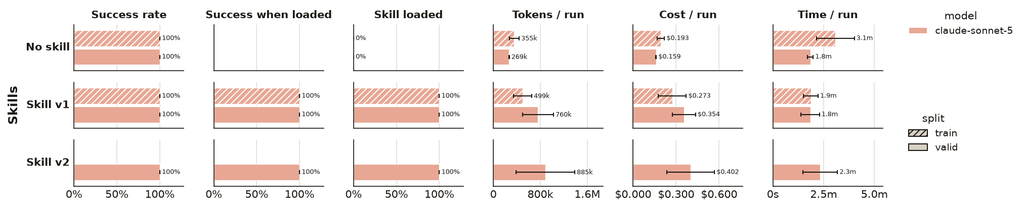

### signature

**train:** `kang2018_lognorm.h5ad` in the working directory holds Kang et al. 2018 PBMCs: log-normalised values in `X` (`normalize_total` to 10,000 then `log1p`); `obs` columns `sample` (one id per patient x condition, e.g. `patient_101_ctrl`), `replicate` (patient), `label` (`ctrl` or `stim`, interferon-beta) and `cell_type`. Take only the cells whose `cell_type` is B cells (subset first, then score). Score the gene set `ifn` (ISG15, IFI6, IFIT1, IFIT3, MX1, OAS1, IFITM3, LY6E, IRF7, RSAD2, ISG20, IFI44L) in every cell with scanpy `sc.tl.score_genes`: ctrl_size 50, n_bins 25, random_state 0, use_raw False; require at least 5 of the set's genes in the data. Average the score per `sample` (samples nest in `label`, the groups). As a control, also score 20 random gene sets of the same size drawn from the other genes (seed 0) the same way. Save the results tables and figures in the working directory. Report only the `sample` with the highest mean score. Genome reference: GRCh37 (hg19), 10x Cell Ranger hg19 annotation.

**valid:** `kang2018_lognorm.h5ad` in the working directory holds Kang et al. 2018 PBMCs: log-normalised values in `X` (`normalize_total` to 10,000 then `log1p`); `obs` columns `sample` (one id per patient x condition, e.g. `patient_101_ctrl`), `replicate` (patient), `label` (`ctrl` or `stim`, interferon-beta) and `cell_type`. Take only the cells whose `cell_type` is B cells (subset first, then score). Score the gene set `mhc2` (HLA-DRA, HLA-DRB1, HLA-DPA1, HLA-DPB1, HLA-DQA1, HLA-DQB1, CD74) in every cell with scanpy `sc.tl.score_genes`: ctrl_size 50, n_bins 25, random_state 0, use_raw False; require at least 5 of the set's genes in the data. Average the score per `sample` (samples nest in `label`, the groups). As a control, also score 20 random gene sets of the same size drawn from the other genes (seed 0) the same way. Save the results tables and figures in the working directory. Report only the `sample` with the highest mean score. Genome reference: GRCh37 (hg19), 10x Cell Ranger hg19 annotation.

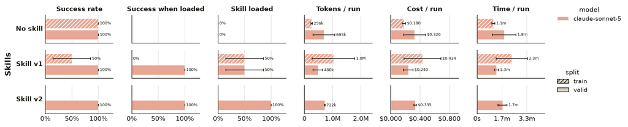

### tfact

**train:** `kang2018_lognorm.h5ad` in the working directory holds Kang et al. 2018 PBMCs: log-normalised values in `X` (`normalize_total` to 10,000 then `log1p`); `obs` columns `sample` (one id per patient x condition, e.g. `patient_101_ctrl`), `replicate` (patient), `label` (`ctrl` or `stim`, interferon-beta) and `cell_type`. Take the `ctrl` cells. `collectri_human.tsv` is the CollecTRI network (columns `source`, `target`, `weight`). Infer TF activity per cell with decoupler's univariate linear model (`dc.mt.ulm`, tmin 5). Then rank the sources per `cell_type` against the rest with `dc.tl.rankby_group` (reference `rest`, method `t-test_overestim_var`). Save the results tables and figures in the working directory. Report only the source with the highest statistic in CD8 T cells. Genome reference: GRCh37 (hg19), 10x Cell Ranger hg19 annotation.

**valid:** `kang2018_lognorm.h5ad` in the working directory holds Kang et al. 2018 PBMCs: log-normalised values in `X` (`normalize_total` to 10,000 then `log1p`); `obs` columns `sample` (one id per patient x condition, e.g. `patient_101_ctrl`), `replicate` (patient), `label` (`ctrl` or `stim`, interferon-beta) and `cell_type`. Take the `ctrl` cells. `collectri_human.tsv` is the CollecTRI network (columns `source`, `target`, `weight`). Infer TF activity per cell with decoupler's univariate linear model (`dc.mt.ulm`, tmin 5). Then rank the sources per `cell_type` against the rest with `dc.tl.rankby_group` (reference `rest`, method `t-test_overestim_var`). Save the results tables and figures in the working directory. Report only the source with the highest statistic in CD14+ Monocytes. Genome reference: GRCh37 (hg19), 10x Cell Ranger hg19 annotation.

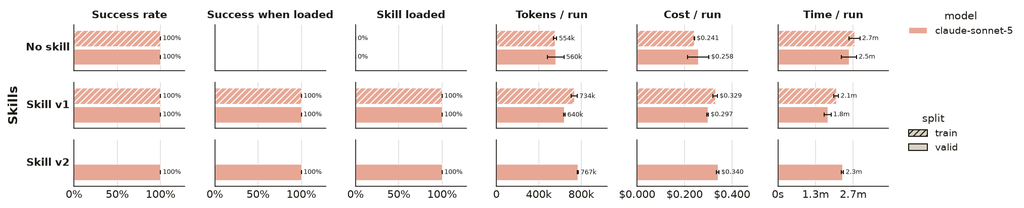

### traj

**train:** `struct_traj.h5ad` in the working directory holds an embedded single-cell dataset: log-normalised values in `X`, a neighbour graph (`uns['neighbors']`, `obsp['connectivities']`), a UMAP in `obsm['X_umap']`, and `obs` column `cluster` (groups `g1` to `g7`). Infer the trajectory with scanpy, keeping the stored neighbour graph (do not recompute it). Run PAGA on `cluster`. Run a diffusion map with 10 components and `random_state` 0. The root cell is the first cell of group `g1` in obs order; run diffusion pseudotime (DPT) from it with 10 diffusion components and no branching. A pair of groups is a PAGA edge when its connectivity is >= 0.2. Cells with infinite pseudotime are left out of the group medians. Save the pseudotime table, the PAGA connectivity table and figures (PAGA graph, UMAP coloured by pseudotime, pseudotime per group) in the working directory. Report only `<number of PAGA edges>/<group with the highest median pseudotime>`, for example `3/g5`. Genome reference: none, synthetic genes.

**valid:** `struct_traj.h5ad` in the working directory holds an embedded single-cell dataset: log-normalised values in `X`, a neighbour graph (`uns['neighbors']`, `obsp['connectivities']`), a UMAP in `obsm['X_umap']`, and `obs` column `cluster` (groups `g1` to `g7`). Infer the trajectory with scanpy, keeping the stored neighbour graph (do not recompute it). Run PAGA on `cluster`. Run a diffusion map with 8 components and `random_state` 1. The root cell is the first cell of group `g2` in obs order; run diffusion pseudotime (DPT) from it with 8 diffusion components and no branching. A pair of groups is a PAGA edge when its connectivity is >= 0.42. Cells with infinite pseudotime are left out of the group medians. Save the pseudotime table, the PAGA connectivity table and figures (PAGA graph, UMAP coloured by pseudotime, pseudotime per group) in the working directory. Report only `<number of PAGA edges>/<group with the highest median pseudotime>`, for example `3/g5`. Genome reference: none, synthetic genes.

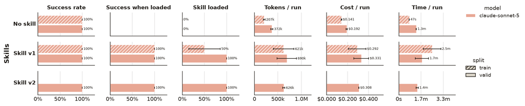

## Skill versions

Why each version was written, and what changed from its parent.

### Skill v1

initial draft

(no rationale recorded)

Initial version — no parent to diff against.

### Skill v2

parent: v1 · sha256:026e0ac2761f…

#### What changed

Rewrote only the top-level `sc-pipelines` router's YAML `description` (the one thing the  
agent sees before deciding whether to open the skill at all; nested per-pipeline SKILL.md  
files are never separately listed, so this is the single lever for every task in this  
skill). Left every pipeline's own SKILL.md body untouched.

The new description (1) names a few more generic method keywords that tasks actually use  
-- rank_genes_groups, Wilcoxon, Spearman, Pearson, consensus NMF, cNMF, mashr, variance  
partitioning -- alongside the existing pipeline names, and (2) adds one explicit clause:  
fire even when the task already spells out its own step-by-step method, and check for a  
fixed script before writing one by hand.

#### Why

wiki/REGRESSIONS.md flags "programs" (gene-program and cNMF discovery) as a train  
regression: noskill passed 2/2, v1 passed only 1/2. Per wiki/programs/observations.md and  
hypothesis.md (tag description-fixable), the router never loaded in either v1 run, so both  
agents hand-wrote the full cNMF pipeline from scratch, and one burned all its turns on that  
before finishing -- a failure mode the ready-made gene_programs.py script would have  
avoided. I confirmed from the rep_1 transcript that the agent never touched the skills  
directory except for one incidental "ls -la" listing right at the very end of the  
(truncated) run -- it never opened the router at all -- and confirmed in the gene-programs  
pipeline's own SKILL.md that the script's fixed defaults (density-threshold 2 keeps all  
components, median-of-cluster consensus, per-replicate seeding from a seed flag) already  
match this task's explicit spec, so loading the skill would have produced the right answer  
quickly. The miss isn't a keyword gap -- "gene programs" was already in the old description  
-- it's that the task read as fully self-specified, and the agent chose to just implement  
it rather than open the skill. The same pattern (never loaded, but happened to pass anyway  
via the model's own knowledge) shows up for "grouptest" and "markers". The new closing  
clause targets exactly that trigger-avoidance pattern, and the added method keywords match  
vocabulary the earlier description lacked at the router level even though it already  
existed deeper in the per-pipeline tables.

The other flagged regression, "signature", is tagged not-skill-fixable in  
wiki/signature/hypothesis.md: the failing run's skill script already produced the correct  
answer, and the loss came from an unrelated post-hoc edit loop (fighting a hook) that ate  
the remaining turns before answer.md was written. No skill-side lever exists for that, so I  
left it alone per the instructions on not-skill-fixable gaps.

I did not touch any pipeline's body: "annotate", "ccc", "embed", "mofa", and "tfact" all  
show the skill loading and the fixed CLI and body contract working correctly when it does,  
which is evidence the bodies are fine as written.

SKILL.md

|  | v1 |  | v2 |
| --- | --- | --- | --- |
| 1 | --- | 1 | --- |
| 2 | name: sc-pipelines | 2 | name: sc-pipelines |
| 3 | description: >- | 3 | description: >- |
| 4 | Router to tested, deterministic single-cell and omics pipeline scripts: QC, | 4 | Router to tested, deterministic scripts for single-cell and bulk-omics analyses whose |
| 5 | normalisation, embedding, annotation, markers, pseudobulk DE, composition, group | 5 | exact numeric answer depends on parameter and formula choices an ad-hoc script is likely |
| 6 | tests, signatures, gene programs, TF activity, cell-cell communication, | 6 | to get slightly wrong: QC and doublet filtering, normalisation, embedding, clustering, |
| 7 | trajectory, velocity, MOFA and more. Fire on any of those analyses. | 7 | cell-type annotation, marker genes (rank_genes_groups), pseudobulk differential |
|  |  | 8 | expression, cell-type composition and differential abundance, group-comparison or |
|  |  | 9 | correlation tests (Wilcoxon, Spearman, Pearson), longitudinal mixed models, gene-set |
|  |  | 10 | enrichment, gene-program discovery (consensus NMF, cNMF), gene-signature scoring, TF or |
|  |  | 11 | pathway activity, cell-cell communication, trajectory and pseudotime, RNA velocity, MOFA |
|  |  | 12 | multi-omics factor analysis, mashr effect sharing, and variance partitioning. Fire on any |
|  |  | 13 | of those analyses, even when the task already spells out its own step-by-step method -- |
|  |  | 14 | check whether a fixed script covers it before writing one by hand. |
| 8 | --- | 15 | --- |
| 9 |  | 16 |  |
| 10 | # sc-pipelines | 17 | # sc-pipelines |
| … |  |  |  |

gene-programs/scripts/__pycache__/palettes.cpython-312.pyc

|  | v1 |  | v2 |
| --- | --- | --- | --- |
|  |  | 1 | <binary file> |

gene-programs/scripts/__pycache__/plots.cpython-312.pyc

|  | v1 |  | v2 |
| --- | --- | --- | --- |
|  |  | 1 | <binary file> |

gene-programs/scripts/__pycache__/skillkit.cpython-312.pyc

|  | v1 |  | v2 |
| --- | --- | --- | --- |
|  |  | 1 | <binary file> |

gene-programs/scripts/__pycache__/theme.cpython-312.pyc

|  | v1 |  | v2 |
| --- | --- | --- | --- |
|  |  | 1 | <binary file> |

## Runs

Full data: report.csv

| arm | split | task | model | rep | skill loaded | reason | turns | total tok | cost / run $ | time | transcript |
| --- | --- | --- | --- | --- | --- | --- | --- | --- | --- | --- | --- |
| noskill | test | annotate | claude-sonnet-5 | 1 | — | ok | 14 | 592,580 | 0.267 | 5.3m | view |
| noskill | test | annotate | claude-sonnet-5 | 2 | — | ok | 9 | 368,318 | 0.201 | 4.7m | view |
| noskill | test | ccc | claude-sonnet-5 | 1 | — | ok | 11 | 446,987 | 0.221 | 2.2m | view |
| noskill | test | ccc | claude-sonnet-5 | 2 | — | ok | 10 | 406,164 | 0.214 | 3.8m | view |
| noskill | test | embed | claude-sonnet-5 | 1 | — | ok | 20 | 915,098 | 0.384 | 5.3m | view |
| noskill | test | embed | claude-sonnet-5 | 2 | — | ok | 12 | 506,460 | 0.246 | 3.7m | view |
| noskill | test | grouptest | claude-sonnet-5 | 1 | — | ok | 9 | 367,966 | 0.209 | 1.6m | view |
| noskill | test | grouptest | claude-sonnet-5 | 2 | — | ok | 7 | 273,365 | 0.167 | 2.4m | view |
| noskill | test | markers | claude-sonnet-5 | 1 | — | ok | 8 | 315,168 | 0.177 | 1.5m | view |
| noskill | test | markers | claude-sonnet-5 | 2 | — | ok | 12 | 478,148 | 0.225 | 1.9m | view |
| noskill | test | mofa | claude-sonnet-5 | 1 | — | ok | 17 | 797,899 | 0.386 | 4.2m | view |
| noskill | test | mofa | claude-sonnet-5 | 2 | — | ok | 10 | 421,658 | 0.239 | 1.4m | view |
| noskill | test | pbde | claude-sonnet-5 | 1 | — | ok | 6 | 232,625 | 0.163 | 2.9m | view |
| noskill | test | pbde | claude-sonnet-5 | 2 | — | ok | 13 | 563,824 | 0.347 | 4.5m | view |
| noskill | test | programs | claude-sonnet-5 | 1 | — | max_turns | 31 | 1,589,188 | 0.679 | 6.9m | view |
| noskill | test | programs | claude-sonnet-5 | 2 | — | ok | 25 | 1,367,725 | 0.704 | 6.3m | view |
| noskill | test | qc | claude-sonnet-5 | 1 | — | ok | 8 | 319,875 | 0.176 | 1.9m | view |
| noskill | test | qc | claude-sonnet-5 | 2 | — | ok | 13 | 542,295 | 0.256 | 2.7m | view |
| noskill | test | signature | claude-sonnet-5 | 1 | — | ok | 6 | 235,307 | 0.164 | 2.2m | view |
| noskill | test | signature | claude-sonnet-5 | 2 | — | ok | 7 | 270,006 | 0.169 | 1.5m | view |
| noskill | test | tfact | claude-sonnet-5 | 1 | — | ok | 13 | 529,244 | 0.232 | 2.9m | view |
| noskill | test | tfact | claude-sonnet-5 | 2 | — | ok | 16 | 683,037 | 0.278 | 3.7m | view |
| noskill | test | traj | claude-sonnet-5 | 1 | — | ok | 9 | 355,147 | 0.186 | 2.7m | view |
| noskill | test | traj | claude-sonnet-5 | 2 | — | ok | 14 | 586,621 | 0.290 | 2.1m | view |
| noskill | train | annotate | claude-sonnet-5 | 1 | — | ok | 7 | 268,397 | 0.156 | 4.9m | view |
| noskill | train | annotate | claude-sonnet-5 | 2 | — | ok | 8 | 312,783 | 0.175 | 5.0m | view |
| noskill | train | ccc | claude-sonnet-5 | 1 | — | ok | 10 | 402,909 | 0.205 | 2.5m | view |
| noskill | train | ccc | claude-sonnet-5 | 2 | — | ok | 8 | 316,207 | 0.186 | 2.3m | view |
| noskill | train | embed | claude-sonnet-5 | 1 | — | ok | 15 | 649,690 | 0.296 | 3.8m | view |
| noskill | train | embed | claude-sonnet-5 | 2 | — | ok | 14 | 614,947 | 0.297 | 4.3m | view |

[output cut: 138 more lines]